# Iris Dataset Statistics Lab

Alex Hurtado Desaulniers

# Libraries

```
library(tidyverse)
```

# Load the iris dataset

```
data(iris)
```

```
# Changing names of each column
colnames(iris) <- c("SepalLen", "SepalWid", "PetalLen", "PetalWid", "Species")
```

```
# checking  first few rows
head(iris)
```

|  | SepalLen | SepalWid | PetalLen | PetalWid | Species |
| --- | --- | --- | --- | --- | --- |
| 1 | 5.1 | 3.5 | 1.4 | 0.2 | setosa |
| 2 | 4.9 | 3.0 | 1.4 | 0.2 | setosa |
| 3 | 4.7 | 3.2 | 1.3 | 0.2 | setosa |
| 4 | 4.6 | 3.1 | 1.5 | 0.2 | setosa |
| 5 | 5.0 | 3.6 | 1.4 | 0.2 | setosa |
| 6 | 5.4 | 3.9 | 1.7 | 0.4 | setosa |

```
view(iris)
```

[output not shown]

## Questions:

1. How many numeric columns are in the dataset?
2. How many species are included?
3. What is the range of SepalLen? (min and max)
4. 4 columns.
5. 3 unique species.
6. the range of SepalLen is (4.3, 7.9).

# Summary Statistics

Calculate mean, median, variance, SD for numeric columns

```
sapply(iris[,1:4], mean)
```

```
SepalLen SepalWid PetalLen PetalWid
5.843333 3.057333 3.758000 1.199333
```

```
sapply(iris[,1:4], median)
```

```
SepalLen SepalWid PetalLen PetalWid
    5.80     3.00     4.35     1.30
```

```
sapply(iris[,1:4], var)
```

```
 SepalLen  SepalWid  PetalLen  PetalWid
0.6856935 0.1899794 3.1162779 0.5810063
```

```
sapply(iris[,1:4], sd)
```

```
 SepalLen  SepalWid  PetalLen  PetalWid
0.8280661 0.4358663 1.7652982 0.7622377
```

```
4.35-3.758
```

```
[1] 0.592
```

## Questions:

1. Which variable has the largest spread?
2. Which has the smallest spread?
3. How does the mean compare to the median for PetalLen?
4. What does a large variance indicate?
5. PetalLen has the highest spread, given it has the highest standard deviation.
6. SepalWid has the smallest spread, given it has the smallest standard deviation.
7. For PetalLen the median is .592 units above the mean.
8. Large Variance indicates a large amount of spread from the mean; a large amount of data is (relatively) far away from the mean.

# Summary by Species

```
aggregate(SepalLen ~ Species, data=iris, FUN=mean)
```

| Species | SepalLen |
| --- | --- |
| setosa | 5.006 |
| versicolor | 5.936 |
| virginica | 6.588 |

```
aggregate(PetalWid ~ Species, data=iris, FUN=var)
```

| Species | PetalWid |
| --- | --- |
| setosa | 0.01110612 |
| versicolor | 0.03910612 |
| virginica | 0.07543265 |

## Questions:

1. Which species has the largest SepalLen on average?
2. Which species shows the most variability in PetalWid?
3. What does this tell you about the characteristics of different species?
4. Virginica has the largest average SepalLen.
5. Virginica shows the most variability in PetalWid.
6. possibly because of Virginica having the largest average SepalLen it may also possess a wide variance for PetalWid in correlation.

# Visualizations

### Histogram of SepalLen

```
hist(iris$SepalLen,
     main="Sepal Length Distribution",
     xlab="Sepal Length (cm)",
     col="pink",
     border="black")
```

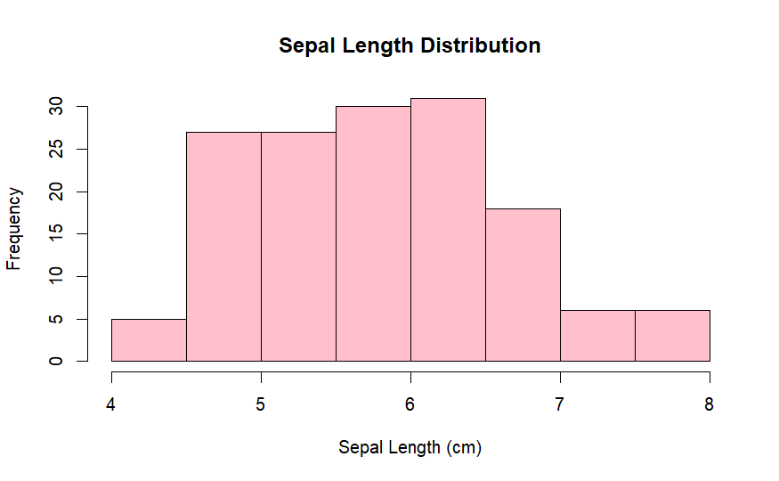

## Questions:

1. What is the shape of the distribution (symmetric, skewed)?
2. Are there any unusually low or high values?
3. The distribution appears *slightly* right skewed.
4. values between 4-4.5 and 7-8 appear unusually low compared to the rest of the data

# Boxplot of PetalLen by Species

```
boxplot(PetalLen ~ Species,
        data=iris,
        main="Petal Length by Species",
        ylab="Petal Length (cm)",
        col=c("pink","skyblue","purple"))
```

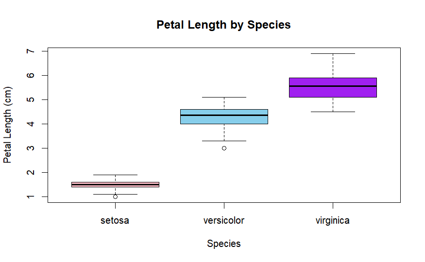

## Questions:

1. Which species has the longest petals?
2. Are there any outliers visible?
3. How do the distributions differ between species?
4. Virginicia has the longest median petals and longest single petal overall compared to the other species.
5. Yes, Setosa and Versicolor both possess an outlier below each respective low whisker.
6. The distribution between species is varied, Virginicia has the highest median and largest IQR overall, with Versicolor not far behind Virginicia. Setosa possess the smallest IQR and lowest overall median Petal Length(cm).

# Correlation Matrix

```
cor_matrix <- cor(iris[,1:4])
cor_matrix
```

```
           SepalLen   SepalWid   PetalLen   PetalWid
SepalLen  1.0000000 -0.1175698  0.8717538  0.8179411
SepalWid -0.1175698  1.0000000 -0.4284401 -0.3661259
PetalLen  0.8717538 -0.4284401  1.0000000  0.9628654
PetalWid  0.8179411 -0.3661259  0.9628654  1.0000000
```

## Questions:

# Interpretation

Write a short paragraph (3-5 sentences) answering:

- Which variables best distinguish species?
- How could a scientist use these statistics in real life?
- Do the histograms, boxplots, and correlations tell a consistent story?
- The Variable(s) that best distinguish species from one another may be Petal Length and Sepal Width, Petal Length shows a determinable and consistent difference in length across the three species and Sepal Width has the lowest variance which may make it useful for consistent (non-variable) determination of species. A scientist could use these statistics in real world applications to determine the specific species of a flower in order to be sure the data they collect for specific species is correct. The historgrams, boxplots, and correlations tell a consistent story across the three species each showing notable differences to differentiate the three species of flower from one another.